# For uniform regions ideal lenses with equal f/# create equal irradiance

## Contents

- Background
- Uniform scene
- Create two ideal lenses
- In class I described why two lenses with the same f/# produce an equal sensor irradiance when the input is a uniform patch.
- The equality is not true for patterns, such as dots or lines.
- This script uses ISETCam to illustrate the calculations and explain how these observations are reconciled.

## Background

However, the image from the larger diameter lens is magnified (larger). The light collected is greater, but it is spread out over more of the image plane. The magnification (spreading out of the image) counters the fact that more photons are gathered from a point. The two factors - light gathering and magnification - cancel each other out. So for a uniform patch the two lenses produce the same irradiance.

## Uniform scene

First, initialize ISETCam.

```matlab
ieInit
```

Create a uniform scene.

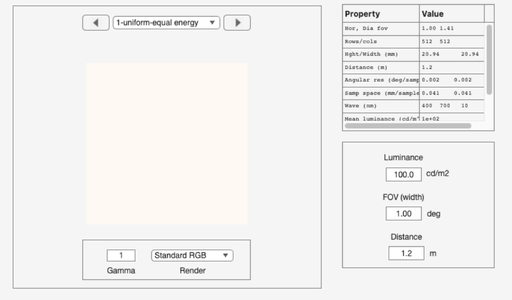

```matlab
imSize = 512;
scene = sceneCreate('uniform ee',imSize);
scene = sceneSet(scene,'fov',1);
sceneWindow(scene);
```

## Create two ideal lenses

The two lenses have the same f/# but different focal lengths and therefore apertures. First lens

```
aperture 1.500000 mm
f number 4.000000

Mean illuminance 3.062561 lux
f number 4.000000
aperture 3.000000 mm

Mean illuminance 3.032319 lux
```

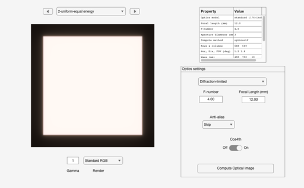

```matlab
% One focal length
oi = oiCreate;
oi = oiSet(oi,'optics focal length',6e-3);
fprintf('aperture %f mm\n',oiGet(oi,'optics diameter','mm'));
fprintf('f number %f\n',oiGet(oi,'optics fnumber'));
oi = oiCompute(oi,scene);
oiWindow(oi);
% Here is the mean illuminance of the optical image.  The illuminance is a
% weighted sum of the irradiances at different wavelengths.
fprintf('\nMean illuminance %f lux\n',oiGet(oi,'mean illuminance'))
% *Second lens: double the focal length, same f/#*

oi2 = oiSet(oi,'optics focal length',oiGet(oi,'optics focal length')*2);
fprintf('f number %f\n',oiGet(oi2,'optics fnumber'));
fprintf('aperture %f mm\n',oiGet(oi2,'optics diameter','mm'));

oi2 = oiCompute(oi2,scene);
oiWindow(oi2);
fprintf('\nMean illuminance %f lux\n',oiGet(oi2,'mean illuminance'))
```

The small difference is probably something to do with the edge. Single line comparison Now, compare what happens when we create an image of a single line.

The two lenses have the same f/#, and therefore they spread the light from the line over the same space - the linespread of two lenses is the same when the f/# is the same. You will see this in the plots, although it may not be obvious from the images. But notice: The spatial resolution of the optical image differs when we change the focal length because the magnification is changed.

Here is a thin line

```matlab
scene = sceneCreate('line',512);
scene = sceneSet(scene,'fov',1);
```

Here is the linespread with the short focal length oi

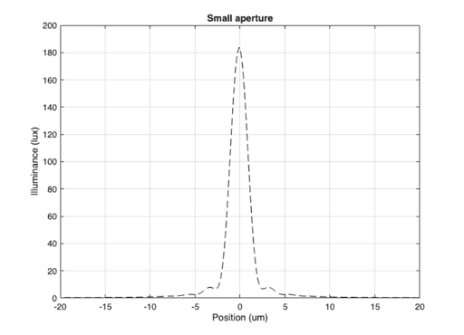

```matlab
oi = oiCompute(oi,scene);
% oiWindow(oi);

% A point on the horizontal line defines the line.
% So we choose (x,y) = [1 256], which is in the middle of the image
data1 = oiPlot(oi,'illuminance hline',[1 256]);
h = get(gca,'Children'); set(h(1),'Color','black','LineStyle','--')
set(gca,'xlim',[-20 20],'xtick',(-20:5:20));
title('Small aperture');

% If you want to plot a horizontal line for each wavelength, use this
% oiPlot(oi,'irradiance hline',[1 256],500);
% set(gca,'xlim',[-20 20],'xtick',[-20:5:20])
```

Now with the optics with double the focal length, but leave the f/# fixed.

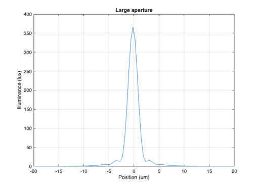

```matlab
oi2 = oiCompute(oi2,scene);
data2 = oiPlot(oi2,'illuminance hline',[1 256]);
set(gca,'xlim',[-20 20],'xtick',(-20:5:20));
title('Large aperture');
```

Here is an overlay of the two curves, showing that more rays get in from a single thin line.

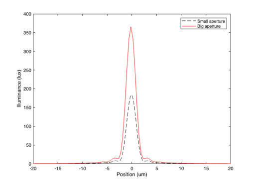

```matlab
ieNewGraphWin;
plot(data1.pos,data1.data,'k--',data2.pos,data2.data,'r-');
set(gca,'xlim',[-20 20],'xtick',(-20:5:20));
xlabel('Position (um)'); ylabel('Illuminance (lux)');
legend({'Small aperture','Big aperture'})
```

The two lines spread by the same amount, because they are very thin lines imaged by ideal lenses with the same f/#. But the line from the lens with the larger aperture has higher illuminance. This seems to be the opposite of what we saw with the uniform field. So, how do we explain this? Magnification The explanation is arises from considerieng the image magnification. We can calculate the impact using a grid stimulus like this, where we control the separation between the grid lines. Let's start with a grid where the lines are separated.

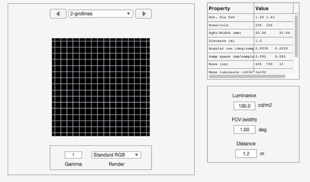

```matlab
sep = 16;
scene = sceneCreate('grid lines',256,sep);
scene = sceneSet(scene,'fov',1);
sceneWindow(scene);
```

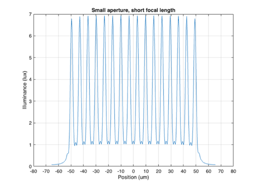

```matlab
oi = oiCompute(oi,scene); % oiWindow(oi);
data1 = oiPlot(oi,'illuminance hline',[1 256]);
set(gca,'xlim',[-80 80],'xtick',(-80:10:80)); title('Small aperture, short focal length')
```

The longer focal length has a different pattern.

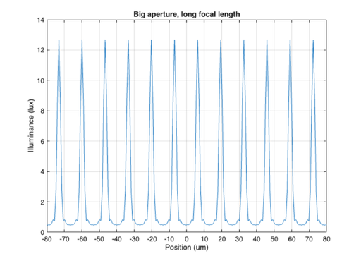

```matlab
oi2 = oiCompute(oi2,scene);
oiPlot(oi2,'illuminance hline',[1 256]);
set(gca,'xlim',[-80 80],'xtick',(-80:10:80)); title('Big aperture, long focal length')
```

Let's repeat the calculation as we reduce the separation between the grid lines. Remember: When there is no separation, we have a uniform field, of course.

Even with a separation of 8, the lines from the short focal length merge together and appear to form a uniform irradiance image. This merging happens to the longer focal length case with a separation of 4.

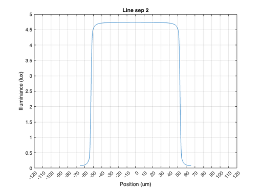

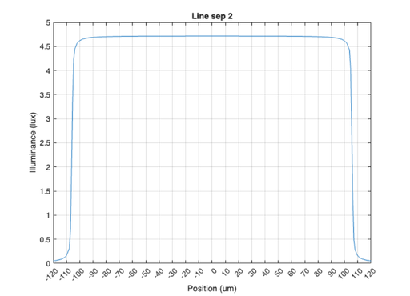

```matlab
sep = 2;   % 8, 4, 2
scene = sceneCreate('grid lines',256,sep);
scene = sceneSet(scene,'fov',1);
oi = oiCompute(oi,scene);
oi2 = oiCompute(oi2,scene);
ieNewGraphWin;
data = oiPlot(oi,'illuminance hline',[1 256]);
set(gca,'xlim',[-120 120],'xtick',(-120:10:120),'ylim',[0 5]);
title(sprintf('Line sep %d',sep));
data2 = oiPlot(oi2,'illuminance hline',[1 256]);
set(gca,'xlim',[-120 120],'xtick',(-120:10:120),'ylim',[0 5]);
title(sprintf('Line sep %d',sep));
```

[Published with MATLAB® R2025b](https://www.mathworks.com/products/matlab/)